# _20240223_dataraw_fm1_orbit

```python
from math import floor
import warnings

import numpy as np
import pandas as pd
import matplotlib
import matplotlib.pyplot as plt
from pathlib import Path
from astropy.io import fits as fitsio
from scipy.stats import linregress
```

These are some utility functions for reading acquisition files and calibration reports:

```python
def pandas_from_LV0d5(fits: Path):
    fits_path = Path(fits)
    with fitsio.open(fits_path) as fits_file:
        fits_data = fits_file[-1].data
        df = pd.DataFrame(np.array(fits_data).byteswap().newbyteorder())
    # fixes first buffer missing ABT
    start_t = floor(df[df["TIME"] > 1].iloc[0]["TIME"]) - 1
    df.loc[df["TIME"] < 1, "TIME"] += start_t

    df = df.reset_index(level=0).rename({"index": "SID"}, axis="columns")
    columns = ["ADC", "CHN", "QUADID", "NMULT", "TIME", "SID"]
    types = ["int32", "int8", "string", "int8", "float64", "int32"]
    dtypes = {col: tp for col, tp in zip(columns, types)}

    temp = np.concatenate([df[["ADC" + i, "CHANNEL" + i, "QUADID", "NMULT", "TIME", "SID"]] for i in "012345"])
    temp = temp[temp[:, 0] > 0]
    temp = temp[temp[:, -1].argsort()]
    df = pd.DataFrame(temp, columns=columns)
    df = df.assign(QUADID=df["QUADID"].map({0: "A", 1: "B", 2: "C", 3: "D"})).astype(dtypes)
    return df

def read_report_from_excel(from_path, kind):
    if kind == "calib":
        return pd.read_excel(from_path, index_col=0, sheet_name=None)
    elif kind == "peaks":
        return pd.read_excel(from_path, header=[0, 1], index_col=0, sheet_name=None)
    elif kind == "fits":
        return pd.read_excel(from_path, header=[0, 1], index_col=0, sheet_name=None)
    else:
        raise ValueError("kind must be either 'calib', 'peaks', or 'fits'.")
```

Defines data paths:

```python
PATH = Path().cwd().parent
DATA_PATH = PATH.joinpath("data")

DATAFOLDER = {
    115:  DATA_PATH.joinpath("other").joinpath("T0thr115").joinpath("20220223_FM1_livefromfuckingspace_LV0d5"),
    105: DATA_PATH.joinpath("T0thr105").joinpath("20220622_xxxx_hermes_fm1_55Fe109Cd137Cs_0deg_thr105_LV0d5"),
    95:  DATA_PATH.joinpath("T0thr95").joinpath("20220622_xxxx_hermes_fm1_55Fe109Cd137Cs_0deg_thr95_LV0d5"),
    85:  DATA_PATH.joinpath("T0thr85").joinpath("20220622_xxxx_hermes_fm1_55Fe109Cd137Cs_0deg_thr85_LV0d5"),
}

LV0d5 = {k: v.parent.joinpath(v.name + ".fits") for k,v in DATAFOLDER.items()}
CALIBS = {k: v.joinpath("report_cal.xlsx") for k,v in DATAFOLDER.items()}
EVENTLIST_UNFILTERED = {k: v.joinpath("event_list_unfiltered.fits") for k,v in DATAFOLDER.items()}
```

Check data to be there:

```python
for _, v in [*DATAFOLDER.items(), *LV0d5.items(), *CALIBS.items(), *EVENTLIST_UNFILTERED.items()]:
    print(f"{v} exists: {v.exists()}")
```

```
D:\Dropbox\Progetti\PerformancesPaper\data\other\T0thr115\20220223_FM1_livefromfuckingspace_LV0d5 exists: True
D:\Dropbox\Progetti\PerformancesPaper\data\T0thr105\20220622_xxxx_hermes_fm1_55Fe109Cd137Cs_0deg_thr105_LV0d5 exists: True
D:\Dropbox\Progetti\PerformancesPaper\data\T0thr95\20220622_xxxx_hermes_fm1_55Fe109Cd137Cs_0deg_thr95_LV0d5 exists: True
D:\Dropbox\Progetti\PerformancesPaper\data\T0thr85\20220622_xxxx_hermes_fm1_55Fe109Cd137Cs_0deg_thr85_LV0d5 exists: True
D:\Dropbox\Progetti\PerformancesPaper\data\other\T0thr115\20220223_FM1_livefromfuckingspace_LV0d5.fits exists: True
D:\Dropbox\Progetti\PerformancesPaper\data\T0thr105\20220622_xxxx_hermes_fm1_55Fe109Cd137Cs_0deg_thr105_LV0d5.fits exists: True
D:\Dropbox\Progetti\PerformancesPaper\data\T0thr95\20220622_xxxx_hermes_fm1_55Fe109Cd137Cs_0deg_thr95_LV0d5.fits exists: True
D:\Dropbox\Progetti\PerformancesPaper\data\T0thr85\20220622_xxxx_hermes_fm1_55Fe109Cd137Cs_0deg_thr85_LV0d5.fits exists: True
D:\Dropbox\Progetti\PerformancesPaper\data\other\T0thr115\20220223_FM1_livefromfuckingspace_LV0d5\report_cal.xlsx exists: True
D:\Dropbox\Progetti\PerformancesPaper\data\T0thr105\20220622_xxxx_hermes_fm1_55Fe109Cd137Cs_0deg_thr105_LV0d5\report_cal.xlsx exists: True
D:\Dropbox\Progetti\PerformancesPaper\data\T0thr95\20220622_xxxx_hermes_fm1_55Fe109Cd137Cs_0deg_thr95_LV0d5\report_cal.xlsx exists: True
D:\Dropbox\Progetti\PerformancesPaper\data\T0thr85\20220622_xxxx_hermes_fm1_55Fe109Cd137Cs_0deg_thr85_LV0d5\report_cal.xlsx exists: True
D:\Dropbox\Progetti\PerformancesPaper\data\other\T0thr115\20220223_FM1_livefromfuckingspace_LV0d5\event_list_unfiltered.fits exists: True
D:\Dropbox\Progetti\PerformancesPaper\data\T0thr105\20220622_xxxx_hermes_fm1_55Fe109Cd137Cs_0deg_thr105_LV0d5\event_list_unfiltered.fits exists: True
D:\Dropbox\Progetti\PerformancesPaper\data\T0thr95\20220622_xxxx_hermes_fm1_55Fe109Cd137Cs_0deg_thr95_LV0d5\event_list_unfiltered.fits exists: True
D:\Dropbox\Progetti\PerformancesPaper\data\T0thr85\20220622_xxxx_hermes_fm1_55Fe109Cd137Cs_0deg_thr85_LV0d5\event_list_unfiltered.fits exists: True
```

Build tables for calibration and acquisition files

```python
dfs_lv0d5 = {k: pandas_from_LV0d5(v) for k,v in LV0d5.items()}
dfs_calibs = {k: read_report_from_excel(v, kind="calib") for k,v in CALIBS.items()}
```

An example:

```python
dfs_lv0d5[105].head()
```

|  | ADC | CHN | QUADID | NMULT | TIME | SID |
| --- | --- | --- | --- | --- | --- | --- |
| 0 | 19097 | 26 | B | 2 | 669.900414 | 0 |
| 1 | 18440 | 29 | B | 2 | 669.900414 | 0 |
| 2 | 16924 | 13 | B | 1 | 669.900943 | 1 |
| 3 | 16637 | 14 | B | 2 | 669.901404 | 2 |
| 4 | 16292 | 18 | B | 2 | 669.901404 | 2 |

```python
dfs_calibs[105]["B"].head()
```

| channel | gain | gain_err | offset | offset_err | chi2 |
| --- | --- | --- | --- | --- | --- |
| 1 | 164.819917 | 0.574053 | 16129.477109 | 9.834871 | 66.392624 |
| 2 | 181.261550 | 0.407457 | 15879.580885 | 8.868290 | 27.327731 |
| 3 | 174.105648 | 0.129773 | 15972.814037 | 2.291133 | 5.388548 |
| 5 | 148.887343 | 0.387547 | 16498.526193 | 9.096822 | 37.162483 |
| 6 | 168.730522 | 0.256828 | 15537.712390 | 4.274088 | 18.396592 |

# Single table analysis

Load data for acquisition at threshold 105

```python
thr = 105
df = dfs_lv0d5[thr]
df_calib = dfs_calibs[thr]
```

Now we get, for each channel, the data entry with the lowest ADC:

```python
df_min = df.groupby(["QUADID", "CHN"]).min()
df_min
```

| QUADID | CHN | ADC | NMULT | TIME | SID |
| --- | --- | --- | --- | --- | --- |
| B | 1 | 16384 | 1 | 567.009457 | 6 |
|  | 2 | 16160 | 1 | 567.028445 | 4 |
|  | 3 | 15584 | 1 | 567.019872 | 14 |
|  | 5 | 16078 | 1 | 567.010999 | 36 |
|  | 6 | 15920 | 1 | 567.016163 | 6 |
| ... | ... | ... | ... | ... | ... |
| D | 26 | 15065 | 1 | 567.007204 | 7791 |
|  | 27 | 15621 | 1 | 567.005733 | 7769 |
|  | 28 | 14983 | 1 | 567.011220 | 7769 |
|  | 29 | 16272 | 1 | 567.007204 | 7804 |
|  | 30 | 15757 | 1 | 567.016323 | 7769 |

74 rows × 4 columns

However, to avoid outliers, instead of taking the absolute minimum ADC observed for each channel, we consider the ADC at the .005 percentile.

```python
df_min = df.groupby(["QUADID", "CHN"]).quantile(.005, interpolation="nearest")
```

```python
df_min
```

| QUADID | CHN | ADC | NMULT | TIME | SID |
| --- | --- | --- | --- | --- | --- |
| B | 1 | 16468 | 1 | 673.450770 | 23728 |
|  | 2 | 16260 | 1 | 673.186883 | 23208 |
|  | 3 | 16477 | 1 | 673.641706 | 24111 |
|  | 5 | 16927 | 1 | 673.794363 | 24404 |
|  | 6 | 16029 | 1 | 673.143233 | 19979 |
| ... | ... | ... | ... | ... | ... |
| D | 26 | 15882 | 1 | 673.206605 | 22808 |
|  | 27 | 16511 | 1 | 673.285325 | 22946 |
|  | 28 | 15918 | 1 | 673.309576 | 22986 |
|  | 29 | 16369 | 1 | 672.919727 | 22365 |
|  | 30 | 16586 | 1 | 673.169919 | 22754 |

74 rows × 4 columns

Now we map ADCs to energies using default calibrations:

```python
energies = [
    (df_min.loc[quad, ch]["ADC"] - df_calib[quad].loc[ch].offset) / df_calib[quad].loc[ch].gain
    for quad, ch in df_min.index
]
```

We obtain something like this:

```python
energies[:5]
```

```
[2.053895531756407,
 2.0987303509316124,
 2.895862182948585,
 2.8778390333308734,
 2.911670069462307]
```

# All Tables

We repeat the thing above for all calibration acquisition taken with the FM1 at different threshold levels and temperature 0°C.

```python
energies = {}
for thr in [85, 95, 105, 115]:
    print(f"analyzing threshold {thr}")
    df = dfs_lv0d5[thr]
    df_calib = dfs_calibs[thr]
    df_min = df.groupby(["QUADID", "CHN"]).quantile(.005, interpolation="nearest")
    energies[thr] = [
        (df_min.loc[quad, ch]["ADC"] - df_calib[quad].loc[ch].offset) / df_calib[quad].loc[ch].gain
        if (ch in df_calib[quad].index) else np.nan
        for quad, ch in df_min.index
    ]
```

```
analyzing threshold 85
analyzing threshold 95
analyzing threshold 105
analyzing threshold 115
```

In the previous step we assigned np.nans to noisy channels which counted something during an acquisition but were not calibrated. We throw away these np.nan:

```python
filtered_energies = {
    k: [*filter(lambda x: x is not np.nan, v)]
    for k, v in energies.items()
}
```

Let's boxplot the channel's energy threshold for different DAC threshold values

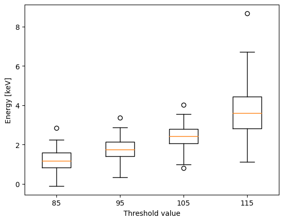

```python
from math import sqrt

plt.boxplot(
    [*filtered_energies.values()]
)
plt.xticks(np.arange(1, len(filtered_energies) + 1), [str(t) for t in filtered_energies.keys()])
plt.minorticks_off()
plt.ylabel("Energy [keV]")
plt.xlabel("Threshold value")
plt.show()
```

Let's consider the minimum of each boxplot. These represent the channel where the lowest energy event were resolved for acquisitions with different threshold level. We print and plot these:

```python
for k, v in filtered_energies.items():
    print(f"At threshold {k}, the minimum energy value among channels is {min(v):.2f}")
```

```
At threshold 85, the minimum energy value among channels is -0.11
At threshold 95, the minimum energy value among channels is 0.34
At threshold 105, the minimum energy value among channels is 0.80
At threshold 115, the minimum energy value among channels is 1.13
```

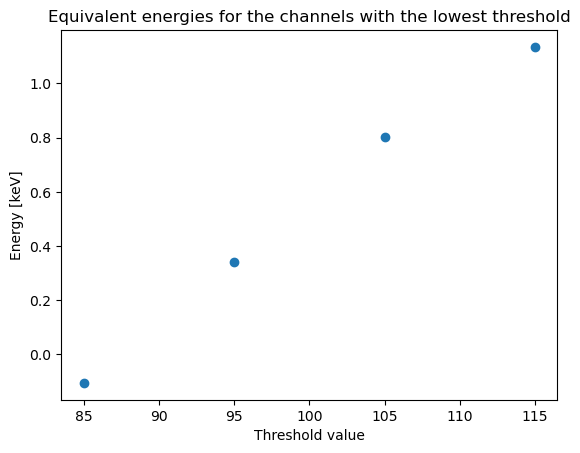

```python
abs_mins = {k: min(v) for k,v in filtered_energies.items()}
plt.plot(abs_mins.keys(), abs_mins.values(), 'o')
plt.xlabel("Threshold value")
plt.ylabel("Energy [keV]")
plt.title("Equivalent energies for the channels with the lowest threshold")
```

Now we make a linear regression of the points above. We won't fit the value from the channel with the lowest enegy observed during the acquisition a threshold 115. The rationale is that the acquisition was very short, so we should have no trust that the actual minimum was indeed observed over the acquisition duration.

```python
lr = linregress([*abs_mins.keys()][:-1], y=[*abs_mins.values()][:-1])
xs = np.arange(85,255,1)
fit = lr.slope * xs + lr.intercept
```

```python
target_energies = [2.5, 3.0, 3.5]
for target_energy in target_energies:
    print(f"DAC threshold corresponding to energy {target_energy} keV is {xs[np.argwhere(fit>target_energy)][0][0]}")
```

```
DAC threshold corresponding to energy 2.5 keV is 143
DAC threshold corresponding to energy 3.0 keV is 154
DAC threshold corresponding to energy 3.5 keV is 165
```

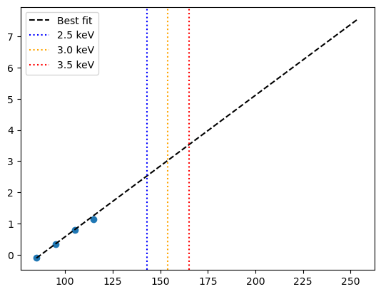

```python
abs_mins = {k: min(v) for k,v in filtered_energies.items()}
plt.scatter(abs_mins.keys(), abs_mins.values())
plt.plot(xs, fit, color="k", linestyle="dashed", label="Best fit")
for c, target_energy in zip(["blue", "orange", "red"], target_energies):
    plt.axvline(xs[np.argwhere(fit>target_energy)][0][0], label=f"{target_energy} keV", linestyle="dotted", color = c)
plt.legend()
```

# Summary

With all the limitations this analysis, if the linear regression holds, **we should raise the global threshold to 165 for pushing the low-energy threshold of the FM1 channel most sensitive to soft events above 3.5 keV**.